# Impact of Weather Events on Population Health & the Economy

Aaron Augustine

Thursday, June 18, 2015

# Synopsis

This report looks to provide insight into which type of weather events have the greatest impact on population health and the economy. Health impact will be defined as the sum of fatalities and injuries. Economic impact will be defined as the sum of property and crop damage in billions of dollars. The goal is to provide an overall impact for both pieces.

This analysis is based on the U.S. National Oceanic and Atmospheric Administration’s (NOAA) storm database. From the analysis we found that TORNADOs have the biggest impact on population health and FLOOD on economy.

# Data Processing

This section outlines the steps used for preparing the data. First I referenced the necessary R packages.

```r
#reference packages used in the analysis
library(downloader)
library(R.utils)
```

```r
library(plyr)
library(ggplot2)
```

This is followed by downloading and unzipping the file.

```r
#Set URL to download file and file name
fileUrl1 <- "https://d396qusza40orc.cloudfront.net/repdata%2Fdata%2FStormData.csv.bz2"
filename <-paste(getwd(),"/repdata_data_StormData.csv.bz2",sep="")

#Download and unzip the file
download(fileUrl1, dest=filename, mode="wb")
bunzip2("repdata_data_StormData.csv.bz2", remove = FALSE, overwrite = TRUE)
```

The unzipped .csv file is read in and stored under rawdata.

```r
#Read in the .csv file
rawdata <- read.csv("repdata_data_StormData.csv",
                    header=TRUE,
                    sep=",",
                    na.strings="NA",
                    stringsAsFactors=FALSE)
```

To improve processing time subset the data down to just the necessary variables.

```r
#list out variables to keep
keepvar<-c("BGN_DATE",
           "EVTYPE",
           "FATALITIES",
           "INJURIES",
           "PROPDMG",
           "PROPDMGEXP",
           "CROPDMG",
           "CROPDMGEXP",
           "REFNUM")

#subset raw data to variables in keepvar
step1<-rawdata[,keepvar]
```

The event types in the data have 985 unique values. In order to make things easier (spelling, similar event types, upper/lower case, etc), I took the 985 types and mapped them to 47 and put them in a .csv file to use to translate the original raw data.

```r
#execute unique command to identify translations to build
unique(rawdata$EVTYPE)
```

[output not shown]

[output cut: 478 more lines]

Here I read in the translation table and merge it against the variable subsetted rawdata. This translation file can be found at https://github.com/AaronAugustine/RepData_PeerAssessment2.

```r
#Read in EVTYPE translation file
trans <- read.csv("EVTYPEtranslations3.csv",
                    header=TRUE,
                    sep=",",
                    na.strings="NA",
                    stringsAsFactors=FALSE)

#merge the EVTYPE in raw data with the translation file to get NEW VALUES
step2 <- merge(step1,trans,
                 by.x="EVTYPE",
                 by.y="OLD",
                 all.x=TRUE)
```

The analysis also requires the impact of property and crop damage. To do this we need to convert the multiplication indicators from “K”, “M”, “B”, etc. to 1000, 1000000, 1000000000. To do this I pulled out the unique values and then mapped them as needed.

```r
unique(rawdata$PROPDMGEXP)
```

```
##  [1] "K" "M" ""  "B" "m" "+" "0" "5" "6" "?" "4" "2" "3" "h" "7" "H" "-"
## [18] "1" "8"
```

```r
unique(rawdata$CROPDMGEXP)
```

```
## [1] ""  "M" "K" "m" "B" "?" "0" "k" "2"
```

```r
#Convert PROPDMGEXP and CROPDMGEXP
tempPROPDMG <- mapvalues(step2$PROPDMGEXP,
                         c("K","M","", "B","m","+","0","5","6","?","4","2","3","h","7","H","-","1","8"),
                         c(1e3,1e6, 1, 1e9,1e6,  1,  1,1e5,1e6,  1,1e4,1e2,1e3,  1,1e7,1e2,  1, 10,1e8))

tempCROPDMG <- mapvalues(step2$CROPDMGEXP,
                         c("","M","K","m","B","?","0","k","2"),
                         c( 1,1e6,1e3,1e6,1e9,1,1,1e3,1e2))
```

From there I applied the mapped values to create numeric property and crop damage values.

```r
step2$PROPTOTALDMG <- as.numeric(tempPROPDMG) * step2$PROPDMG
step2$CROPTOTALDMG <- as.numeric(tempCROPDMG) * step2$CROPDMG
```

In order to provide an overall view of the impact on people I combined fatalities and injuries as a total impact on people in 1000’s. Similarly for the impact on the economy, I did the same for property and crops into damage in billions.

```r
step2$people <- (step2$FATALITIES + step2$INJURIES)/1000
step2$damage <- (step2$PROPTOTALDMG + step2$CROPTOTALDMG)/1000000000
```

Lastly, I summarized the impact of people and the economy across the entire data and rounded the results to one decimal place.

```r
step3<-ddply(step2,c("NEW"),
                     summarize,
                     damage=sum(damage,na.rm=TRUE),
                     people=sum(people,na.rm=TRUE)
             )

step3$damage<-round(step3$damage,digits=1)
step3$people<-round(step3$people,digits=1)
```

# Results

The analysis is focused on answering to main questions.

1. Across the United States, which types of events (as indicated in the EVTYPE variable) are most harmful with respect to population health?
2. Across the United States, which types of events have the greatest economic consequences?

To focus on the event types with the biggest impact, I limited each graph to just the top 10.

```r
chart1<-head(step3[order(step3$people, decreasing=TRUE),],n=10)
chart2<-head(step3[order(step3$damage, decreasing=TRUE),],n=10)
```

From the figure below we can see that TORNADO followed by HEAT are most harmful with respect to population health.

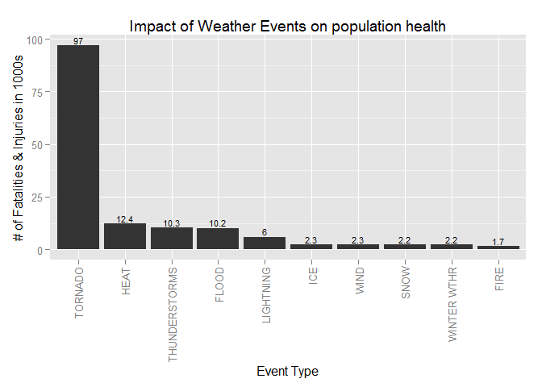

```r
p<-ggplot(chart1, aes(x = reorder(NEW,-people), y = people)) +
    geom_bar(stat = "identity") +
    geom_text(aes(label = people), size = 3, vjust=-.25, hjust=.5) +
    theme(axis.text.x = element_text(angle = 90, vjust = .5, hjust=1)) +
    xlab("Event Type") + ylab("# of Fatalities & Injuries in 1000s") +
    ggtitle("Impact of Weather Events on population health")
p
```

In the figure below, FLOOD has the biggest economic impact. Double the next closest type, HURRICANE.

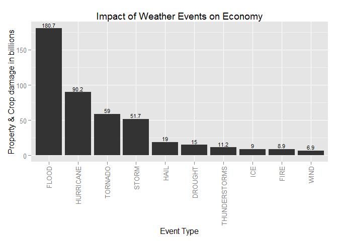

```r
q<-ggplot(chart2, aes(x = reorder(NEW,-damage), y = damage)) +
    geom_bar(stat = "identity") +
    geom_text(aes(label = damage), size = 3, vjust=-.25, hjust=.5) +
    theme(axis.text.x = element_text(angle = 90, vjust = .5, hjust=1)) +
    xlab("Event Type") + ylab("Property & Crop damage in billions") +
    ggtitle("Impact of Weather Events on Economy")
q
```